# 01a Introduction to Biostatistics

Julius-Maximilians-University Würzburg  
Course: “Biostatistics”  
Translational Neuroscience

Dr. Mario Reutter (slides adapted from Dr. Lea Hildebrandt)

# Welcome!

## Hello!

Who am I?

Who are you?

- What is your background?
- Do you have experience with data analysis?
- What’s your attitude towards statistics?

## Using the Slides

- These slides are created directly in R with the quarto extension.
- You can jump to a slide by clicking the three dashes in the bottom left.
- You can conveniently copy R code from the slides with one click and paste it into your RStudio.

```r
print("Hello World")
```

```
[1] "Hello World"
```

## Organizational Issues

- Attendance is mandatory! (I don’t make the rules :) )
  - You may miss one session without giving reasons (recommendation: don’t waste it early!)
  - If you miss additional sessions, please write an email with an explanation (further proof may be required, e.g. doctor’s certificate)
- The course will take place in person
  - Only for students who are not in Würzburg yet, there is an option via Zoom
- We will use these textbooks (Open Educational Resources - freely available online, also linked in WueCampus):
  - Statistical Thinking for the 21st Century: https://statsthinking21.github.io/statsthinking21-core-site/index.html
  - For the R part: Fundamentals of Quantitative Analysis: https://psyteachr.github.io/quant-fun-v2/

## Contents

- From basic probability to (Generalized) Linear Mixed Models
  - Some things may be repetitive for you but this course aims to provide a common starting position for your next semesters
- Input (lecture style) with hands-on R sessions
- In addition, you should read a few pages in the text books  
  ([Statistical Thinking for the 21st Century](https://statsthinking21.github.io/statsthinking21-core-site/), and possibly [Fundamentals of Quantitative Analysis](https://psyteachr.github.io/quant-fun-v2/))
- Project: Independently analyze a dataset (exam with pass or fail grading)

## Project

- Find a dataset that can answer a question you are interested in
  - https://ourworldindata.org/
  - [Statistisches Bundesamt](https://www.destatis.de/)
  - Your own, e.g., from an internship
- preprocess/wrangle it,
- analyze the data,
- and write a short (min. 2-page) report!
  - short intro incl. research question and hypothesis
  - methods (both how the data were acquired and how they are analyzed)
  - results (incl. at least one plot)
  - and a short discussion.
    - *All* these parts should be *at least half a page* long.

## Calender

| Date | Topic | Reading | Project Deadlines |
| --- | --- | --- | --- |
| 17.10. | General & R Intro | ST21: 1-3, QF: 1-3 |  |
| 24.10. | Probability | ST21: 4, QF: 4-6 |  |
| 31.10. | Data Wrangling | ST21: 4, QF: 4-6 |  |
| 07.11. | Data Visualization | QF: 7 |  |
| 14.11. | Sampling | ST21: 7-8, QF: 8 |  |
| 21.11. | Probability & Sampling in R | ST21: 7-8, QF: 8 |  |
| 28.11. | Hypothesis Testing | ST21: 9-10 |  |
| 05.12. | Comparing Means & Categories | ST21: 12, 15 | Dataset |
| 12.12. | Exercises (t-Tests, Chi²) | ST21: 12, 15 |  |
| 19.12. | (Generalized) Linear Models | ST21: 12-13 | Research Question & Hypotheses |
| 26.12. & 02.01. | *Christmas & New Year’s* |  |  |
| 09.01. | Exercises (GLM) | ST21: 12-13 |  |
| 16.01. | Linear Mixed Models | ST21: 14 |  |
| 23.01. | Exercises (LMM) | ST21: 14 | Analysis |
| 30.01. | Troubleshooting Your Report |  |  |
| 06.02. | Reproducible Research | ST21: 18 | Report |

ST21: Statistical Thinking for the 21st Century  
QF: Fundamentals of Quantitative Analysis (QuantFun)

# Why Statistics?

## Why is it important that YOU know statistics?

- You’re doing a *research* master!
  - Research = Reading & understanding papers (esp. the analyses)
  - Designing your own experiments, analyze data, interpret results
- We live in an increasingly data-centric world
  - Knowing how to wrangle and analyze data is a valuable skill
- Facts & data literacy matter more than ever!
  - Fake News, “Lying with stats”, Reproducibility Crisis
  - Being able to call bullshit (https://www.callingbullshit.org/)
- “I only believe in statistics that I doctored myself” ― Winston S. Churchill
  - However: “It is easy to lie with statistics, but easier to lie without them” ― Frederick Mosteller

## What is Statistical Thinking?

- “a systematic way of thinking about how we describe the world and **use data [to] make decisions and predictions**, all in the context of the inherent **uncertainty** that exists in the real world.” (Poldrack, Preface of ST21)
- “Statistical thinking is a way of **understanding** a complex world by describing it in relatively **simple terms** that nonetheless capture **essential aspects** of its structure or function, and that also provide us some idea of how **uncertain** we are about that knowledge.” (Poldrack, Chapter 1)

## Why is Statistical Thinking Important?

- data literacy vs. intuition/heuristics/anecdotal evidence
  - Public discourse about Covid-19, migration, etc. (e.g., “50% of people in intensive care are vaccinated”)

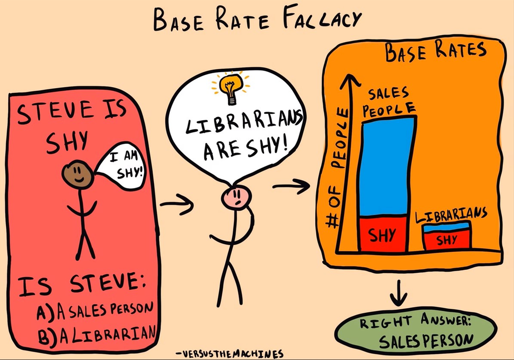

Base Rate Fallacy

## What can Statistics Do For Us?

- **Describe** patterns by summarizing/breaking down data (“descriptive statistics”)
- **Decide** whether one thing is better than another, given the uncertainty (“inferential statistics”)
- **Predict** how other people would “behave” (generalize to new observations)

## The Big Ideas

- **Learning from data**: Update our beliefs
- **Aggregation**: How to summarize the data to draw meaningful conclusions?
- **Uncertainty**: Probabilistic evidence
- **Sampling from the population**: Which people etc. do we select?

## Causality

Correlation does not imply causation… but is a hint!

Example: Smoking = less risk for Parkinson’s disease? ([Godwin-Austen et al., 1982](http://dx.doi.org/10.1136/jnnp.45.7.577); [Chen et al., 2010](https://doi.org/10.1212/WNL.0b013e3181d55f38))

--> confounding factors?

e.g., individual dopaminergic activity => addiction & motor function

Randomized Controlled Trials (RCT) as the solution?

## What are Data?

- What do you think are data?
- qualitative vs. quantitative
  - qualitative?
    - open questions, descriptions… can potentially be coded into categories
  - quantitative?
    - numeric, can be averaged etc.

## What are Data? (2)

- Data types
  - character/string: text (qualitative)
  - factors/categories
  - types of numbers (quantitative)
    - binary: 0 or 1, TRUE or FALSE (logical)
    - integers: whole numbers
    - real numbers: decimals/fractions
- discrete vs. continuous
  - discrete: finite set of particular values (0 or 1, scale from 1 to 10)
  - continuous: real numbers that fall into particular range (e.g., brain activity, visual analoge scale)
- What data type is *eye color*?

## What is a Data Set?

- a collection of data
- usually organized into rows and columns (like an excel spreadsheet)
  - rows: participants/animals/cells…
  - columns: **variables**!
    - each variable contains one type of measurement
  - table cells = unique observations of variables per participant etc.

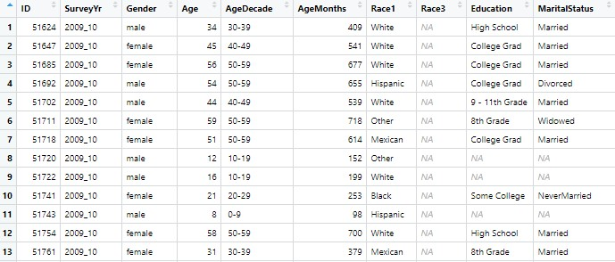

NHANES dataset

## What Makes a Good Measurement?

- What is being measured?
  - constructs vs. proxies: need to be well-defined! (Difficult)
  - measurement error
    - random: e.g., variation in reaction times of same participant across trials
    - systematic: e.g., miscalibrated eye-tracking device
- Do we have a “gold standard” to compare the measurement to?

## Reliability

Correlation of a measurement with “itself”

- Internal reliability (consistency)
- Test-retest reliability (stability)
- Inter-rater reliability (agreement)

Correlation with other variables can’t be higher than reliability (cf., [Wilmer et al., 2012, Table 1](https://doi.org/10.1080/02643294.2012.753433))!

## Validity

Are we measuring the construct we’re interested in?

- Face validity: Does it intuitively make sense? First reality check!
- Construct validity
  - convergent validity: Related to similar measures that should measure the same construct
  - divergent validity: Is it unrelated to other measures?
- Predictive validity: Is it predictive of other outcomes? (e.g., intelligence & job success)

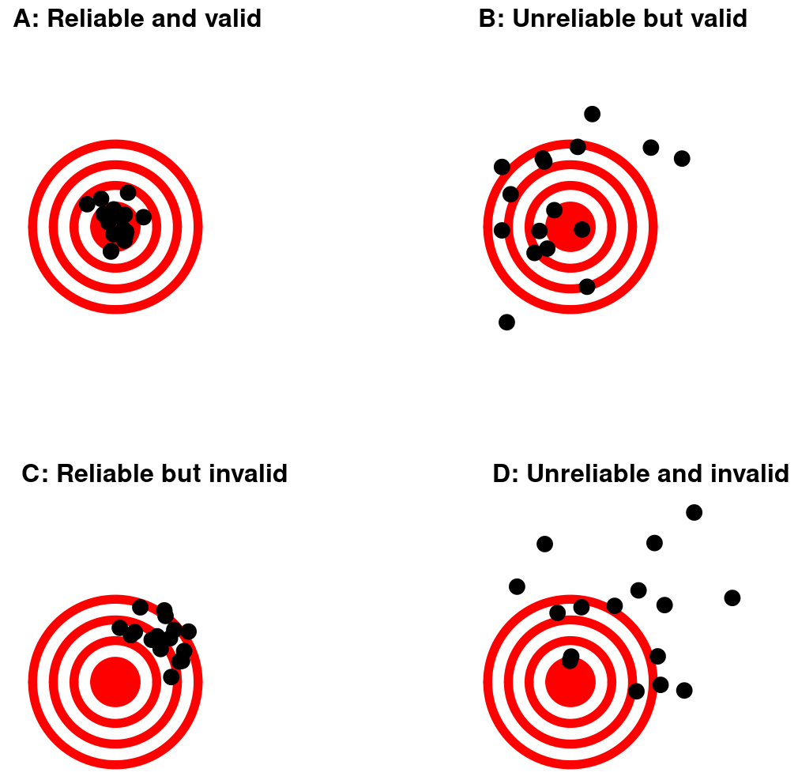

Reliability & Validity

## Summarizing Data

- Throwing away (some of the) information!
  - extract the quintessence of the data (important for forming *models*)
  - make predictions
- Counts, frequencies, percentages, averages

# Thanks!

Learning objective today:

- Why is statistics important?
- What are data?
- What is reliability and validity?

Next:

- R session: “Intro to R”
  - please [install R](https://www.r-project.org/) & [RStudio](https://posit.co/download/rstudio-desktop/)!
    - Installation tutorial: https://learningstatisticswithr-bookdown.netlify.app/intror
    - You can also already install Rtools, which will be needed later: https://cran.r-project.org/bin/windows/Rtools/
- Theory: Models